# Naive B cell project

Summary Workflow

**Or Shemesh : 204065767**

# Introduction

In this project we working with Naive B cells data set. We will try to create a model that will predict the subject's health status based on the features of his repertoire sequences.

**Data Pre-Proccecing**

The data was obtained from a plate of naive B cells derived from blood samples of 98 patients, 51 of whom were diagnosed with celiac disease. (It is known that there are specific biomarkers that allow us to specifically sequence naive B cells with error rates ranging from 10-20%). We get FASTA files, which we tranfer in IGBLAST and MAKE_DB algorithms to align the sequences to the known human reference. At the end of the MAKE DB process, we have a table that the raws represent patient's repertoire sequences, and the different columns describe different characteristics of the sequence.

**Project goal**

In this work we will investigate a range of state-of-the-art machine learning methods for classification, including **random forests, logistic regression and support vector regression**. These models will be applied to predict the clinically-relevant subject states based on observed repertoire features. **Cross-validation** will be used to prevent over-fitting, and **feature selection** will allow for identification of the most relevant properties.

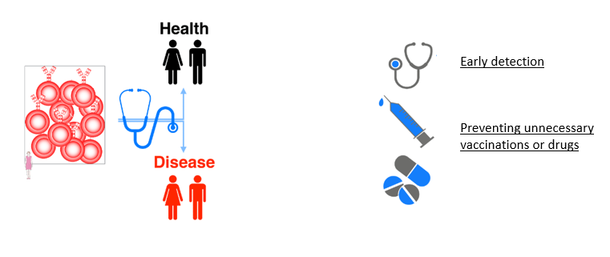

```python
from IPython.display import Image
Image(filename='the_project_goal.png')
```

We hope that the tools we develop will pave the way for Ig repertoire data to be used for diagnostic and prognostic purposes, and allow for tailored treatment for each individual based on their immune system characteristics. A satisfying classification model will approve a future low cost test for early detection of celiac patients, save unnecessary medical procedures and might reveal unique signatures for potential antibodies development.

**Input:** patient’s BCR repertoire

**Output:** A clinical status for the patient given by the probability of being a Celiac patient.

# The problem

It is very difficult to do the prediction by this dataset type (Naive B cell). Because a Naive B cells is a B cell that has not been exposed to an antigen. In other words, they do not carry information about patient's immune history. Moreover, there are no former works on naive BCR analysis for early detection of celiac.  
The diversity and structure of disease antigen-specific sequence motufs in immune repertoires remains enigmatic.  
**Machine learning** is an ideal approach for predicting disease antibody-specific motifs as it captures long-range (3D-structural) motifs using only the linear B cell receptor sequence.

# Contents

Step 1: Data Overview  
1.2: Feature Engineering  
1.3: Summary of New features  
Step 2: Basic Questions  
2.1: EDA: exploratory data analysis  
2.1.1: Standardization  
2.1.2: First visualization  
2.2: Kolmogorov Smirnov test  
2.2.1: Extract features based on KS test  
2.2.2: Visualization  
Step 3: Feature Selection - 2 methods  
3.1: Feature Selection- Our New Method - based on KS test  
3.1.1: Visualize the impact of feature selected used PCA (Principal component Analysis)  
3.2: Extract important features used Random Forest  
3.2.1: Visualize the impact of feature selected used PCA (Principal component Analysis)  
3.3: Comparison between the chosen best informative features by KS vs Random-Forest  
3.4: Visualize the impact of 'informative_features' on health status  
3.4.1: Continued analyzed based on Visualization  
Step 4: Learning Algorithms  
4.1: Load packages  
4.2: Random Forest  
4.2.1: Tuned Hyperparameter - Random Forest  
4.2.2: Prediction and Evaluations - Random Forest  
4.3: SVC  
4.3.1: Tuned Hyperparameter - SVC  
4.3.2: Prediction and evaluations - SVC  
4.4: Logistic Regression  
4.4.1: Tuned hyperparameters - LR  
4.4.2: Prediction and evaluation - LR  
4.5: Gaussian Naive Bayes  
4.5.1: Evaluate classifier for all the features  
4.5.2: Evaluate GaussianNB model for the informative features  
4.6: Compare Machine Learning Algorithms and improve by cross validation  
4.7: Learning curve of GaussianNB and SVM  
4.7.1: LC - For all the features  
4.7.2: LC - For selected features  
Step 5: Control  
5.1: Control - Without selecting features  
5.2 Control - For informative columns  
5.3 Control - compare algorithms scores  
5.4 Control Results  
Step 6: New machine learning function  
6.1: with SVM model  
6.2: With Gaussian Naive Bayes model  
6.3: New ML - Control  
6.6: Final Prediction Results  
Step 7: Conclusion and Results  
The next steps

# Required packages:

Before starting, install and load the following packages.

```python
#%% Import python modules:
import numpy as np
from sklearn.neighbors import BallTree
from sklearn.metrics import f1_score
from sklearn.preprocessing import scale
from sklearn.decomposition import PCA
from sklearn.manifold import TSNE
from collections import Counter
import matplotlib.pyplot as plt
import seaborn as sns
import itertools
from sklearn import preprocessing
import urllib.request as ur
from gzip import GzipFile
import pandas as pd
%matplotlib inline
```

# Step1: Data Overview

First, before making pre-processing, we look at the raw dataframe. We create violin graphs in order to observe an interesting feature. The interesting feature will be one that gives us a big difference between cohorts.

```python
# READ FILE
import csv
dfALLs2 = pd.read_table("dfALL_after_order_genes.csv",error_bad_lines=False,sep="\t")
```

```python
dfALLs2.head()
```

|  | CDR3_AA_ACIDIC | CDR3_AA_ALIPHATIC | CDR3_AA_AROMATIC | CDR3_AA_BASIC | CDR3_AA_BULK | CDR3_AA_CHARGE | CDR3_AA_GRAVY | CDR3_AA_LENGTH | CDR3_AA_POLARITY | CLIN | ... | V_SEQ_LENGTH | V_SEQ_START | V_GENE | V_ALLELE | V_FAMILY | D_GENE | D_ALLELE | D_FAMILY | J_GENE | J_FAMILY |
| --- | --- | --- | --- | --- | --- | --- | --- | --- | --- | --- | --- | --- | --- | --- | --- | --- | --- | --- | --- | --- | --- |
| 0 | 0.105263 | 0.410526 | 0.315789 | 0.052632 | 15.510000 | -1.003173 | -0.368421 | 19.0 | 8.021053 | Healthy | ... | 292 | 1 | IGHV4-34 | IGHV4-34*01 | IGHV4 | IGHD1-26 | IGHD1-26*01 | IGHD1 | IGHJ5 | IGHJ5*02 |
| 1 | 0.071429 | 0.771429 | 0.142857 | 0.071429 | 13.752143 | -0.001683 | 0.414286 | 14.0 | 8.128571 | Healthy | ... | 293 | 1 | IGHV3-21 | IGHV3-21*01 | IGHV3 | IGHD6-19 | IGHD6-19*01 | IGHD6 | IGHJ4 | IGHJ4*02 |
| 2 | 0.100000 | 0.390000 | 0.300000 | 0.050000 | 14.960000 | -1.007156 | -0.440000 | 20.0 | 8.000000 | Healthy | ... | 293 | 1 | IGHV1-69 | IGHV1-69*01 | IGHV1 | IGHD3-3 | IGHD3-3*01 | IGHD3 | IGHJ6 | IGHJ6*03 |
| 3 | 0.117647 | 0.058824 | 0.470588 | 0.058824 | 15.103529 | -1.007731 | -0.900000 | 17.0 | 7.917647 | Healthy | ... | 295 | 1 | IGHV3-23 | IGHV3-23*01 | IGHV3 | IGHD3-3 | IGHD3-3*01 | IGHD3 | IGHJ5 | IGHJ5*02 |
| 4 | 0.111111 | 0.594444 | 0.277778 | 0.055556 | 15.718889 | -1.009332 | 0.011111 | 18.0 | 7.722222 | Healthy | ... | 295 | 1 | IGHV1-69 | IGHV1-69*01 | IGHV1 | IGHD5-18 | IGHD5-18*01 | IGHD5 | IGHJ6 | IGHJ6*03 |

5 rows × 55 columns

```python
# drop unrelevant columns
dfALLs2.drop(list(dfALLs2.filter(regex = 'Unnamed')), axis = 1, inplace = True)
raw_data = dfALLs2.iloc[:,9:-8]
raw_data.info()
```

```
<class 'pandas.core.frame.DataFrame'>
RangeIndex: 3003858 entries, 0 to 3003857
Data columns (total 38 columns):
CLIN                  object
CONSCOUNT             int64
D_CALL                object
D_GERM_LENGTH         float64
D_GERM_START          float64
D_SEQ_LENGTH          float64
D_SEQ_START           float64
FUNCTIONAL            bool
INDELS                bool
IN_FRAME              bool
JUNCTION              object
JUNCTION_LENGTH       int64
J_CALL                object
J_GERM_LENGTH         int64
J_GERM_START          int64
J_SEQ_LENGTH          int64
J_SEQ_START           int64
MUTATED_INVARIANT     float64
NP1_LENGTH            int64
NP2_LENGTH            float64
PRCONS                object
PRIMER                object
SAMPLE                object
SEQORIENT             object
SEQUENCE_ID           object
SEQUENCE_IMGT         object
SEQUENCE_INPUT        object
SEQUENCE_VDJ          object
SEX                   object
STOP                  bool
SUBJECT               float64
V_CALL                object
V_GERM_LENGTH_IMGT    int64
V_GERM_LENGTH_VDJ     int64
V_GERM_START_IMGT     int64
V_GERM_START_VDJ      int64
V_SEQ_LENGTH          int64
V_SEQ_START           int64
dtypes: bool(4), float64(7), int64(13), object(14)
memory usage: 790.7+ MB
```

## 1.2 Feature Engineering

#### The dataframe columns:

Due to biological reasons, we don't need all the columns for our prediction model, but maybe the combination of some columns give us a more informative feature. *In the presentation format, there has a description of all the features we finally used for the learning machines. (See Celiac.ppt)*

**Assigning datatypes:**

We need to make sure our column types and levels of measurement before doing analysis.  
For this purpose, we convert information represented by a string to numbers. We did this by displaying the expression frequency of each string feature.  
For example, V3 gene is expressed in 30% of a person's sequence repertoire.

In order to create a dataframe with target column (represent each subject's repertoire, 98 rows) and features columns we reconstruct this dataframe: We don't use all the columns for analyzing. But create a new table with significant biology features that include only float type values by looking on the column's frequency per subject_name.  
Finally, we have data which all the features columns are in float type.

**Deal with Nan variables**

We have 2 steps of dealing with Nan variables:

- 1) In the first raw data we got, have some Nan variable when antibody's sequence is not recognize properly. In this case, for each subject, we delete sequence rows(from his repertoire) with Nan value in our interested columns (features).
- 2) After we create all the new features' tables, we merge them together in order to get one big dataframe with all the new features of each subject. At this stage, we got a Nan value blocks in specific column, for subjects that no expression this feature. Since each column represents the frequency of feature's appear in the repertoire, we inserted zeros instead of Nan values.

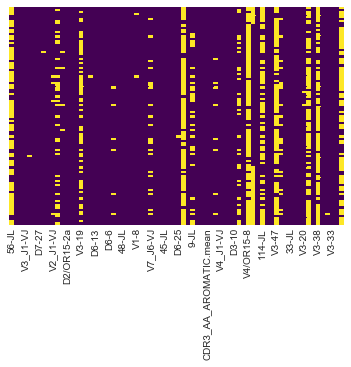

```python
from IPython.display import Image
Image(filename='null_values_in_merge_table.png')
```

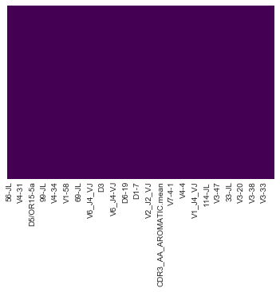

```python
from IPython.display import Image
Image(filename='null_after_insert_zeros.png')
```

Check if we have null values

```python
df.iloc[:,3:].isnull().values.any()
```

```
False
```

**The final dataset**

Repertoire properties, including gene usage and H-CDR3 physicochemical properties, were calculated using **Alakazam**.

```python
# you can find the creation of this table on 'combine_features_tables' notebook
df_per_target = pd.read_pickle('VDJ_CDR3_FUNC_ISOTYPE_DseqL')
print(df_per_target.shape)
df = df_per_target
df.head()
```

```
(98, 1046)
```

|  | SUBJECTN | CLIN | SEX | V1 | V2 | V3 | V4 | V5 | V6 | V7 | ... | 33.0-DseqL | 34.0-DseqL | 35.0-DseqL | 36.0-DseqL | 37.0-DseqL | 5.0-DseqL | 6.0-DseqL | 7.0-DseqL | 8.0-DseqL | 9.0-DseqL |
| --- | --- | --- | --- | --- | --- | --- | --- | --- | --- | --- | --- | --- | --- | --- | --- | --- | --- | --- | --- | --- | --- |
| 0 | BC_10 | Healthy | NaN | 0.232505 | 0.025345 | 0.431113 | 0.243586 | 0.058649 | 0.008521 | 0.000281 | ... | 0.000076 | 0.000127 | 0.000025 | 0.000025 | 0.000000 | 0.049911 | 0.067015 | 0.057405 | 0.051976 | 0.051160 |
| 1 | BC_11 | Healthy | NaN | 0.213667 | 0.026993 | 0.466993 | 0.238861 | 0.044784 | 0.008565 | 0.000137 | ... | 0.000096 | 0.000019 | 0.000058 | 0.000039 | 0.000000 | 0.048053 | 0.061529 | 0.054425 | 0.050902 | 0.050729 |
| 2 | BC_12 | Healthy | NaN | 0.208928 | 0.025766 | 0.401013 | 0.307753 | 0.032451 | 0.010218 | 0.013870 | ... | 0.000000 | 0.000224 | 0.000000 | 0.000000 | 0.000000 | 0.050220 | 0.065361 | 0.056734 | 0.051886 | 0.050319 |
| 3 | BC_13 | Healthy | NaN | 0.208727 | 0.048319 | 0.402105 | 0.284245 | 0.049473 | 0.006873 | 0.000258 | ... | 0.000247 | 0.000073 | 0.000058 | 0.000029 | 0.000015 | 0.049292 | 0.058772 | 0.051546 | 0.047576 | 0.047881 |
| 4 | BC_14 | Healthy | NaN | 0.248387 | 0.022468 | 0.449467 | 0.224517 | 0.047101 | 0.007833 | 0.000227 | ... | 0.000302 | 0.000267 | 0.000107 | 0.000036 | 0.000089 | 0.045476 | 0.053533 | 0.045690 | 0.045299 | 0.047415 |

5 rows × 1046 columns

Now, The dataset contains expression levels of 98 subject (rows) over 1043 features (columns)

### 1.3 Summary of New features:

D: Gene & Family usage  
V : Gene & Family usage  
J : Gene usage  
V-J : all possible combination between V and J genes  
JUNCTION LENGTH: column for each type of length  
V-J-JL: all possible combination between V,J and Junction length  
DseqL: D sequence length  
FUNC: functionality  
CDR3 properties:  
CDR3_AA_LENGTH: number of amino acids.  
CDR3_AA_GRAVY : grand average of hydrophobicity(GRAVY) index.  
CDR3_AA_BULK : average bulkiness of amino acids.  
CDR3_AA_ALIPHATIC: aliphatic index.  
CDR3_AA_CHARGE: net charge.  
CDR3_AA_BASIC: fraction of informative position that are Arg,His or Lys.  
CDR3_AA_ACIDIC: fraction of informative position that are Asp or Glu.  
CDR3_AA_AROMATIC: fraction of informative positions that are His,Phe,Trp or Tyr.  
**For more information about each feature - See the "Celiac.ppt" file**